# AdvGeoviz_MyLab1

2022-10-28

## Adding my required Libraries

```r
library(ggplot2)
library(sf)
library(tidyverse)
```

## Adding my data

I will be using some census data from the 2010 Ecuadorian census that has been clipped to an area called the “ACUS” which stands for Area of Conservation and Sustainable Use that is located in Manabi, Ecuador. I chose to use this data in order to calculate new attributes that could be of use for my capstone project of highlighting priority areas for restoration within this area.

```r
ACUS<- st_read("C:/EAS_648_AdvGeoviz/Lab1/ACUS_Data/ownership.dbf")
```

## Viewing my data with a simple version of ggplot

The individual polygons are individual census sectors within the larger overall boundary of the ACUS

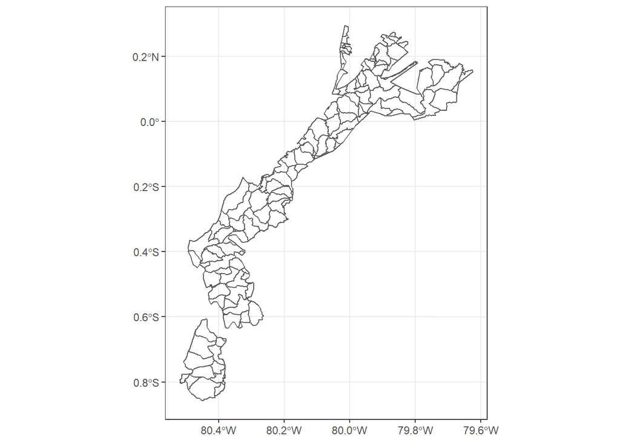

```r
ggplot() +
    geom_sf(data =ACUS,
    fill = NA, alpha = .2) +
    theme_bw()
```

## Adding additional Libraries for more advanced ggplot use

```r
library(sf)
library(ggspatial)
library(viridis)
```

## Viewing the variable “percent_ow” or percent ownership within each sector of the ACUS

This attribute was created using the original census data of landowner counts within each sector. The landowner counts in each sector were divided by the total number of people in each sector, then multiplied by 100 in order to get the percent ownership values for each census sector.

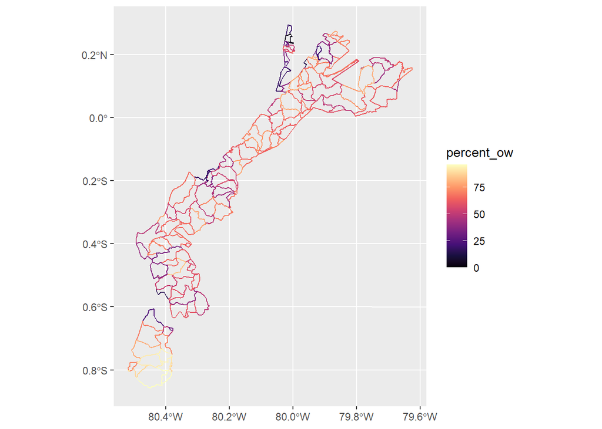

```r
ggplot() +
    geom_sf(data = ACUS, aes(color=percent_ow),
    fill = NA, alpha = .2) +
    scale_colour_gradientn(colours = magma(10))
```

## Using Tmap

```r
library(tmap)
```

## Turning on the interactive mode of Tmap

```r
tmap_mode("view")
```

```
## tmap mode set to interactive viewing
```

## Making the in-depth, interactive, tmap for the ACUS that shows percent ownership for each sector

Overall, this was not incredibly difficult to make but I did have significant issues positioning all of my elements. The legend in particular, did not want to move from its initial position in the top right corner of the map, hence why it is still there and overlaps with the title of the map unfortunately. You can see that in my code, I try in multiple areas (6 to be exact) to move the legend position. This was extremely frustrating and I looked up the functions and arguments and performed the edits that were suggested but nothing ended up working. In order to save my sanity, I decided to just have them overlap and mention this discrepancy.

```r
data("ACUS")
tm_shape(ACUS) +
    tm_polygons("percent_ow", title= "Percent Ownership", legend.outside= TRUE, positon= c("left","bottom"), style='quantile', legend.reverse= TRUE,legend.position = "bottom") +  tm_layout(title= "Percent landownership within the Area of Conservation and Sustainable Use (ACUS) in Manabi, Ecuador") + tmap_options(check.and.fix = TRUE, qtm.scalebar= TRUE, legend.format=list(fun=function(x) paste0(formatC(x, digits=0, format="f"), " %")),  legend.position = c("left","bottom"))+
  tm_borders() +
    tm_fill(legend.position = c("left","bottom")) +
    tm_scale_bar() +
    tm_layout(legend.position = c("left","bottom"))+tm_legend(legend.position = c("left","bottom"))
```

```
## legend.postion is used for plot mode. Use view.legend.position in tm_view to set the legend position in view mode.
## legend.postion is used for plot mode. Use view.legend.position in tm_view to set the legend position in view mode.
```

[interactive chart not shown]

## Creating a Histogram of the percent landownership data using ggplot

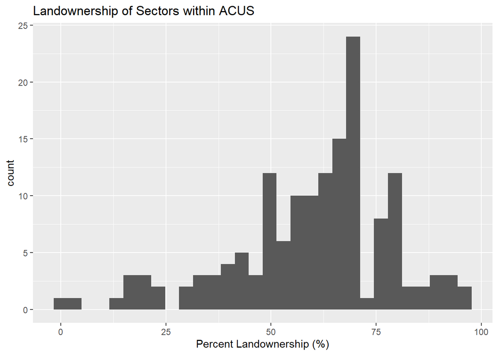

```r
ggplot(ACUS, aes(x=percent_ow)) + geom_histogram()+ scale_x_continuous(name = "Percent Landownership (%)")  + ggtitle("Landownership of Sectors within ACUS")
```

## Lab Assignment Questions

1. Benefits and Challenges of Open Source Data # Benefits: There are many benefits of using open source data, with one of the most self-explanatory being better access to rich, timely, and low-cost data that can lead to data-driven studies that are more sophisticated and robust. In this way, researchers do not have to take and exorbitant amount of time designing and implementing surveys in order to get the data they require. By being able to have this data already linked to geographic coordinates, researchers can look for spatial patterns and correlations quite easily and at a much lower cost of money, time, and energy spent. # Challenges: Just as there are benefits, there are also a considerable amount of challenges with open source data. One of the most obvious challenges being the sheer volume of data itself. This amount of data can be overwhelming to a researcher and can require a considerable amount of cleaning and pre-processing in order to be deemed “usable”. Also it should be noted that these large datasets, do not include all geographic,social, and cultural variables that could act as potential confounding factors and thus researchers need to be hesitant in making grand generalizations/conclusions with just their open source data. Researchers need to be aware that these large open data sources are not exhaustive and there needs to be auxillary research performed in order to make adequate conclusions. In addition, there is always some form of questioning on how credible, accurate, and precise this data is when it could potentially be gathered from literally thousands of different contributers.
2. This HTML itself